# Exploratory Analysis

### Chart 3

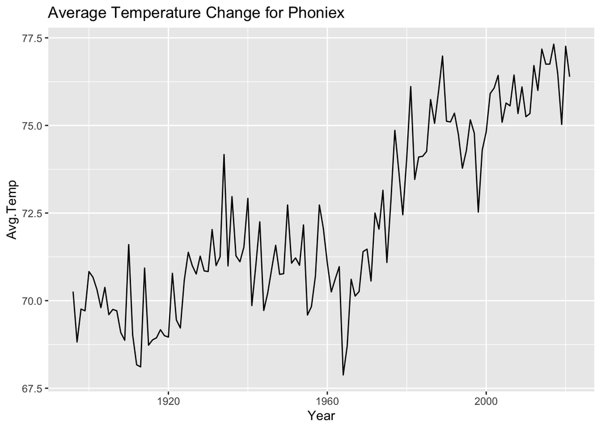

```r
source("./anaylsis.R")

Phoniex_plot
```

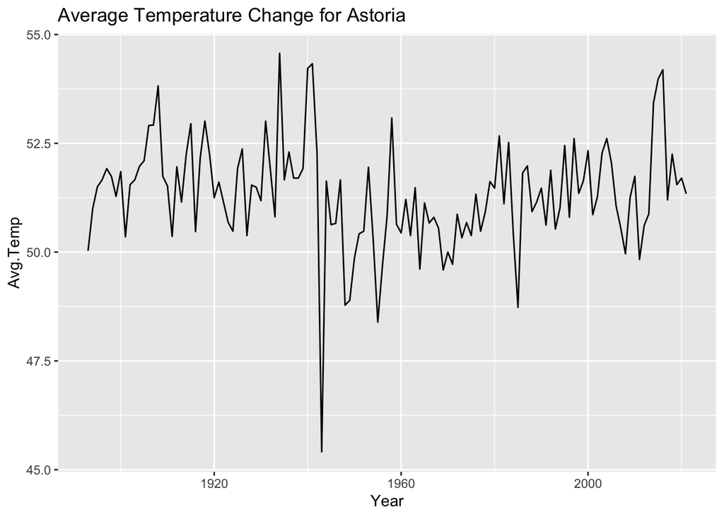

```r
source("./anaylsis.R")

Astoria_plot
```

# Chart 3- Amen

# Includes insights (what information is revealed)

In the chart showing the average temperature of Phoenix, we observe that the temperature hasn’t dipped below 65 degrees for over 120 years, consistently maintaining a warm climate. Over time, this temperature has continued to rise.

In contrast, the chart displaying the average temperature of Astoria reveals significantly lower temperatures compared to Phoenix. The average temperature in Astoria ranges from 45 to 55 degrees. Although there is a dip at some point, the temperature has generally remained within this range.

# Visualization type makes sense for data

Line charts makes sense for the data because they best represent the information we want to share clearly, especially since we are comparing data with high and low values.